# CA0-810196688

اسم پروژه: تمرین کامپیوتری شماره صفر

هدف پروژه: پیش بینی کردن قیمت های اعلام نشده به کمک تحلیل آماری

توضیح کلی پروژه :

در این پروژه در ابتدا با تعدادی از توابع کتابخانه pandas آشنا می شویم سپس با استفاده از این توابع اطلاعات مختلفی از دیتا ست داده شده، که شامل مشخصات مرتبط با ماشین های مختلف می شود، استخراج می کنیم. حال با داشتن اطلاعات فنی ماشین ها و قیمت های بعضی از این ماشین ها تلاش بر این داریم که در نهایت قیمت ماشین هایی که اطلاعات قیمت آن ها داده نشده است را پیش بینی کنیم. با استفاده از کتابخانه گفته شده و همچنین انجام عملیات های آماری مختلف در مورد بخش های مختلف دیتاست، بررسی کردن اطلاعات کامل برخی از ماشین ها، مشاهده و رسم داده ها با کمک کتابخانه matplotlib و در نهایت مشخص کردن تابع تخمین می توانیم به قیمت های مشخص نشده برسیم و آن ها را پیش بینی کنیم.

در این جا کل دیتاست داده شده مرتبط با خودروهایی که در آمریکا فروش می روند را به برنامه اضافه می کنیم و در دیتا فریم mainDataFrame نگهداری می کنیم.

از این دیتاست برای تحلیل کردن و تکمیل اطلاعات قیمت بعضی از خودرو ها استفاده می کنیم.

```python
import pandas as pd
import time
import matplotlib.pyplot as plt
import numpy as np

mainDataFrame = pd.read_csv('car_price_dataset.csv')

mainDataFrame.tail()
# shows by default the last 5 rows of dataFrame but it can be given a desired number of rows to show too
```

|  | car_ID | CarName | fueltype | carlength | carwidth | carheight | curbweight | cylindernumber | enginesize | horsepower | citympg | highwaympg | price |
| --- | --- | --- | --- | --- | --- | --- | --- | --- | --- | --- | --- | --- | --- |
| 200 | 201 | volvo 145e (sw) | gas | 188.8 | 68.9 | 55.5 | 2952 | four | 141.0 | 114.0 | 23 | 28 | 16845.0 |
| 201 | 202 | volvo 144ea | gas | 188.8 | 68.8 | 55.5 | 3049 | four | 141.0 | 160.0 | 19 | 25 | 19045.0 |
| 202 | 203 | volvo 244dl | gas | 188.8 | 68.9 | 55.5 | 3012 | six | 173.0 | 134.0 | 18 | 23 | 21485.0 |
| 203 | 204 | volvo 246 | diesel | 188.8 | 68.9 | 55.5 | 3217 | six | 145.0 | 106.0 | 26 | 27 | 22470.0 |
| 204 | 205 | volvo 264gl | gas | 188.8 | 68.9 | 55.5 | 3062 | four | 141.0 | 114.0 | 19 | 25 | 22625.0 |

```python
mainDataFrame.head()
# shows by default the first 5 rows of dataFrame but it can be given a desired number of rows to show too
```

|  | car_ID | CarName | fueltype | carlength | carwidth | carheight | curbweight | cylindernumber | enginesize | horsepower | citympg | highwaympg | price |
| --- | --- | --- | --- | --- | --- | --- | --- | --- | --- | --- | --- | --- | --- |
| 0 | 1 | alfa-romero giulia | gas | 168.8 | 64.1 | 48.8 | 2548 | four | 130.0 | 111.0 | 21 | 27 | 13495.0 |
| 1 | 2 | alfa-romero stelvio | gas | 168.8 | 64.1 | 48.8 | 2548 | four | 130.0 | 111.0 | 21 | 27 | 16500.0 |
| 2 | 3 | alfa-romero Quadrifoglio | gas | 171.2 | 65.5 | 52.4 | 2823 | six | 152.0 | 154.0 | 19 | 26 | 16500.0 |
| 3 | 4 | audi 100 ls | gas | 176.6 | 66.2 | 54.3 | 2337 | four | 109.0 | NaN | 24 | 30 | 13950.0 |
| 4 | 5 | audi 100ls | gas | 176.6 | 66.4 | 54.3 | 2824 | five | 136.0 | 115.0 | 18 | 22 | NaN |

```python
mainDataFrame.describe()
# Gives some statistical info about the dataFrame like mean, std, min, etc.
```

|  | car_ID | carlength | carwidth | carheight | curbweight | enginesize | horsepower | citympg | highwaympg | price |
| --- | --- | --- | --- | --- | --- | --- | --- | --- | --- | --- |
| count | 205.000000 | 205.000000 | 205.000000 | 205.000000 | 205.000000 | 191.000000 | 182.000000 | 205.000000 | 205.000000 | 185.000000 |
| mean | 103.000000 | 174.049268 | 65.907805 | 53.724878 | 2555.565854 | 125.418848 | 105.747253 | 25.219512 | 30.751220 | 13392.181984 |
| std | 59.322565 | 12.337289 | 2.145204 | 2.443522 | 520.680204 | 39.229587 | 40.288214 | 6.542142 | 6.886443 | 8235.838288 |
| min | 1.000000 | 141.100000 | 60.300000 | 47.800000 | 1488.000000 | 61.000000 | 52.000000 | 13.000000 | 16.000000 | 5118.000000 |
| 25% | 52.000000 | 166.300000 | 64.100000 | 52.000000 | 2145.000000 | 97.000000 | 72.250000 | 19.000000 | 25.000000 | 7788.000000 |
| 50% | 103.000000 | 173.200000 | 65.500000 | 54.100000 | 2414.000000 | 119.000000 | 95.000000 | 24.000000 | 30.000000 | 10295.000000 |
| 75% | 154.000000 | 183.100000 | 66.900000 | 55.500000 | 2935.000000 | 141.000000 | 121.000000 | 30.000000 | 34.000000 | 16503.000000 |
| max | 205.000000 | 208.100000 | 72.300000 | 59.800000 | 4066.000000 | 326.000000 | 288.000000 | 49.000000 | 54.000000 | 45400.000000 |

```python
mainDataFrame.info()
# Gives info for values of each column
```

```
<class 'pandas.core.frame.DataFrame'>
RangeIndex: 205 entries, 0 to 204
Data columns (total 13 columns):
car_ID            205 non-null int64
CarName           205 non-null object
fueltype          205 non-null object
carlength         205 non-null float64
carwidth          205 non-null float64
carheight         205 non-null float64
curbweight        205 non-null int64
cylindernumber    205 non-null object
enginesize        191 non-null float64
horsepower        182 non-null float64
citympg           205 non-null int64
highwaympg        205 non-null int64
price             185 non-null float64
dtypes: float64(6), int64(4), object(3)
memory usage: 20.9+ KB
```

```python
# Replcaing string with numbers to use them in calculation
mainDataFrame = mainDataFrame.replace({"fueltype" : {"gas" : 0 , "diesel" : 1}})
```

```python
# Getting the number of NaN values in each column
mainDataFrame.isna().sum()
```

```
car_ID             0
CarName            0
fueltype           0
carlength          0
carwidth           0
carheight          0
curbweight         0
cylindernumber     0
enginesize        14
horsepower        23
citympg            0
highwaympg         0
price             20
dtype: int64
```

```python
# Replacing NaN values with mean of column values
mainDataFrame.loc[mainDataFrame["price"].notna() , :] = mainDataFrame.loc[mainDataFrame["price"].notna() , :].fillna(mainDataFrame.mean())
```

مزایا و معایب استفاده از میانگین:

بدی استفاده از میانگین می تواند این باشد که اگر داده ها اختلاف زیادی با هم داشته باشند میانگین زیاد مورد خوبی برای استفاده نمی باشد به این شکل که مثلا 90 درصد داده ها 0.1 باشد و 10 درصد بقیه 100 باشند در این صورت میانگین representation خوبی برای داده ها ندارد. و این به معنی biased بودن در این حالت است که مورد بدی می باشد.

خوبی استفاده از میانگین این است که اگر داده ها به شکل بالا نباشند علاوه بر این که میانگین به راحتی قابل محاسبه و اجرا است، معیار خوبی نیز می باشد و باعث biased بودن نمی شود. پس در کل انتخاب میانگین می تواند به کلیت داده ها و توزیع آن ها وابسته باشد.

در این جا سطر هایی که مقدار قیمت آن ها نامشخص هست را از mainDataFrame جدا کرده و در یک دیتافریم دیگر با نام NaNPriceDF ذخیره می کنیم.

```python
NaNPriceDF = mainDataFrame.loc[mainDataFrame["price"].isna() , :]

mainDataFrame = mainDataFrame.loc[mainDataFrame["price"].notna() , :]
```

```python
# Number of cars based on number of cylinders
mainDataFrame["cylindernumber"].value_counts()
```

```
four      143
six        22
five        9
eight       5
two         4
twelve      1
three       1
Name: cylindernumber, dtype: int64
```

```python
# Info related to part 5 of project
mainDataFrame[(mainDataFrame["fueltype"] == 0) & (mainDataFrame["horsepower"] > 100) & (mainDataFrame["citympg"] < 15)]
```

|  | car_ID | CarName | fueltype | carlength | carwidth | carheight | curbweight | cylindernumber | enginesize | horsepower | citympg | highwaympg | price |
| --- | --- | --- | --- | --- | --- | --- | --- | --- | --- | --- | --- | --- | --- |
| 49 | 50 | jaguar xk | 0 | 191.7 | 70.6 | 47.8 | 3950 | twelve | 326.000000 | 262.000000 | 13 | 17 | 36000.0 |
| 73 | 74 | buick century special | 0 | 208.1 | 71.7 | 56.7 | 3900 | eight | 125.418848 | 105.747253 | 14 | 16 | 40960.0 |
| 74 | 75 | buick regal sport coupe (turbo) | 0 | 199.2 | 72.0 | 55.4 | 3715 | eight | 304.000000 | 184.000000 | 14 | 16 | 45400.0 |

```python
print("Number of cars with the given conditions: ")
len(mainDataFrame[(mainDataFrame["fueltype"] == 0) & (mainDataFrame["horsepower"] > 100) & (mainDataFrame["citympg"] < 15)])
```

```
Number of cars with the given conditions:
```

```
3
```

محاسبه میانگین با فراخوانی تابع mean در کتابخانه pandas

```python
print("Mean of cars with gas usage: ")
mainDataFrame[mainDataFrame["fueltype"] == 0].mean()["price"]
```

```
Mean of cars with gas usage:
```

```
13170.738957831325
```

```python
print("Mean of cars with diesel usage: ")
mainDataFrame[mainDataFrame["fueltype"] == 1].mean()["price"]
```

```
Mean of cars with diesel usage:
```

```
15326.894736842105
```

محاسبه میانگین با استفاده از حلقه به شکل حرکت بر روی مقادیر به دست آوردن تعداد و مجموع مقادیر و در نهایت به دست آوردن میانگین

```python
num_gas = 0; sum_price_gas = 0
num_diesel = 0; sum_price_diesel = 0

for _ , car in mainDataFrame.iterrows():
    if(car["fueltype"] == 0):
        num_gas += 1; sum_price_gas += car["price"]
    elif(car["fueltype"] == 1):
        num_diesel += 1; sum_price_diesel += car["price"]

print("Mean of cars with gas usage: " + str(sum_price_gas / num_gas))
print("Mean of cars with diesel usage: " + str(sum_price_diesel / num_diesel))
```

```
Mean of cars with gas usage: 13170.738957831325
Mean of cars with diesel usage: 15326.894736842105
```

به دلیل این که با استفاده از توابع pandas با روش vectorization پیش می رویم از روشی که با حلقه محاسبات را انجام می دهیم سرعت بالاتری خواهیم داشت.

```python
tic_vector = time.time()
mainDataFrame[mainDataFrame["fueltype"] == 0].mean()["price"]
mainDataFrame[mainDataFrame["fueltype"] == 1].mean()["price"]
toc_vector = time.time()

tic_iter = time.time()
for _ , car in mainDataFrame.iterrows():
    if(car["fueltype"] == 0):
        num_gas += 1; sum_price_gas += car["price"]
    elif(car["fueltype"] == 1):
        num_diesel += 1; sum_price_diesel += car["price"]
toc_iter = time.time()

print("Vectorized time: " + str((toc_vector - tic_vector) * 1000) + " ms")
print("Iterative time: " + str((toc_iter - tic_iter) * 1000) + " ms")
```

```
Vectorized time: 8.98122787475586 ms
Iterative time: 29.914379119873047 ms
```

در این جا نمودار histogram ستون های با مقدار عددی نمایش داده شده است.

```
Distribution of each column's values:
```

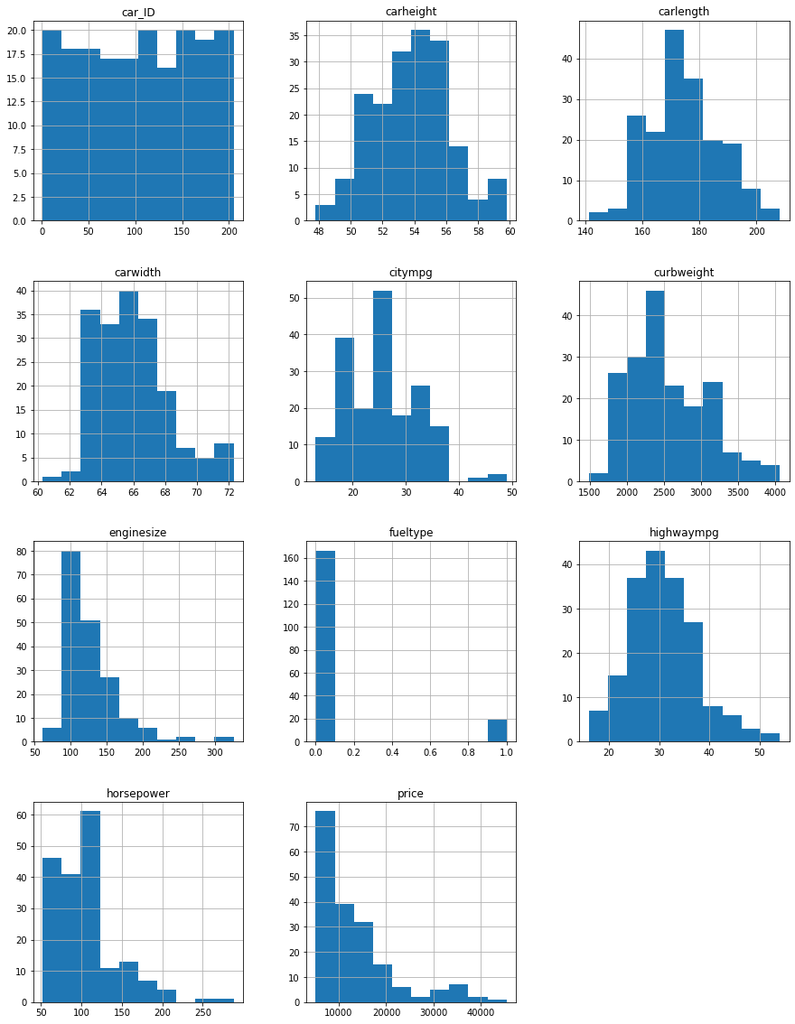

```python
print("Distribution of each column's values:")
mainDataFrame.hist(figsize = (15 , 20));
```

```python
mainDataFrame = mainDataFrame.drop(['CarName', 'fueltype' , 'cylindernumber'], axis = 1)
```

```python
# Normalization

mainDataFrame["price"] = (mainDataFrame["price"] - mainDataFrame["price"].mean()) / mainDataFrame["price"].std()
print("Price column after normalization: ")
mainDataFrame["price"]
```

```
Price column after normalization:
```

```
0      0.012484
1      0.377353
2      0.377353
3      0.067731
5      0.225577
6      0.524272
7      0.671191
8      1.272830
9      0.542384
10     0.368854
11     0.428957
12     0.920103
13     0.936495
14     1.356610
15     2.108810
```

[output cut: 47 more lines]

در این مرحله نمودار مقادیر هر ستون بر اساس مقدار ستون قیمت رسم شده است یعنی هر نقطه نشان دهنده یک خودرو می باشد.

در هر نمایش محور x مقدار یکی از ستون ها و محور y مقدار قیمت می باشد و این که کدام ستون در نمایش آورده شده در اول هر cell نوشته شده است.

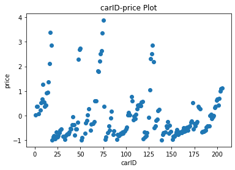

```python
# y => price , x => car_ID
plt.scatter(mainDataFrame["car_ID"] , mainDataFrame["price"]);
plt.title("carID-price Plot");
plt.xlabel("carID");
plt.ylabel("price");
```

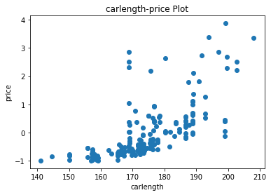

```python
# y => price , x => carlength
plt.scatter(mainDataFrame["carlength"] , mainDataFrame["price"]);
plt.title("carlength-price Plot");
plt.xlabel("carlength");
plt.ylabel("price");
```

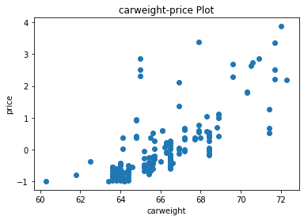

```python
# y => price , x => carweight
plt.scatter(mainDataFrame["carwidth"] , mainDataFrame["price"]);
plt.title("carweight-price Plot");
plt.xlabel("carweight");
plt.ylabel("price");
```

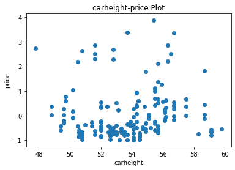

```python
# y => price , x => carheight
plt.scatter(mainDataFrame["carheight"] , mainDataFrame["price"]);
plt.title("carheight-price Plot");
plt.xlabel("carheight");
plt.ylabel("price");
```

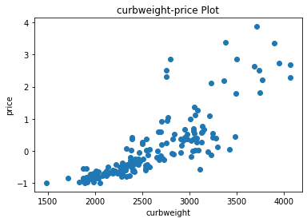

```python
# y => price , x => curbweight
plt.scatter(mainDataFrame["curbweight"] , mainDataFrame["price"]);
plt.title("curbweight-price Plot");
plt.xlabel("curbweight");
plt.ylabel("price");
```

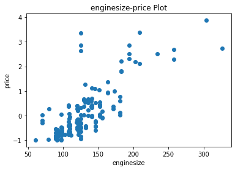

```python
# y => price , x => enginesize
plt.scatter(mainDataFrame["enginesize"] , mainDataFrame["price"]);
plt.title("enginesize-price Plot");
plt.xlabel("enginesize");
plt.ylabel("price");
```

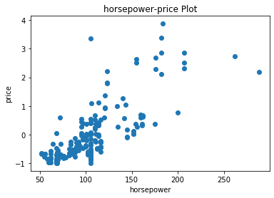

```python
# y => price , x => horsepower
plt.scatter(mainDataFrame["horsepower"] , mainDataFrame["price"]);
plt.title("horsepower-price Plot");
plt.xlabel("horsepower");
plt.ylabel("price");
```

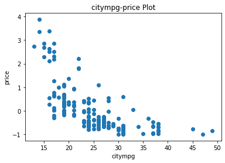

```python
# y => price , x => citympg
plt.scatter(mainDataFrame["citympg"] , mainDataFrame["price"]);
plt.title("citympg-price Plot");
plt.xlabel("citympg");
plt.ylabel("price");
```

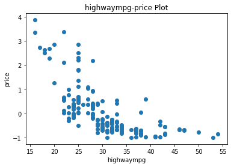

```python
# y => price , x => highwaympg
plt.scatter(mainDataFrame["highwaympg"] , mainDataFrame["price"]);
plt.title("highwaympg-price Plot");
plt.xlabel("highwaympg");
plt.ylabel("price");
```

با مشاهده نمودار های بالا دیده می شود که دو ستون enginesize و curbweight تقریبا با افزایش مقدار قیمت مقدار آن ها نیز به صورت خطی زیاد می شود و در واقع داده ها را می توان با یک خط تا حدودی نمایش داد با توجه به این نکته در ابتدا enginesize و بعد به دلیل مشکل ایجاد شده که در پایین تر توضیح داده شده curbweight انتخاب شده است.

توضیحات آورده شده برای enginesize برای curbweight که پایین تر آورده شده است نیز صادق است.

```python
# engineSize and curbWeight aren't that bad for linear correlation -> I chose engineSize at first
```

در این جا مقادیر دو ستون سایز موتور و قیمت را در یک دیتافریم جدید با نام engineSizeDF ذخیره می کنیم.

```python
engineSizeDF = pd.concat([mainDataFrame["enginesize"] , mainDataFrame["price"]] , axis = 1)
```

در این مرحله با مشاهده نمودار و انتخاب خطی که تخمین خوبی برای داده ها باشد به محاسبه تابع تخمین پرداخته شده است. با بررسی و جستجو در داده ها نقاطی برای هر کدام از خط ها انتخاب شدند که با استفاده از آن ها معادله خط به دست آمد. این چهار معادله خط برای بررسی انتخاب شده اند و همه خطایی کم تر از 0.5 دارند ولی تابع تخمین سوم به دلیل این که کمترین MSE را داشت در نهایت انتخاب شد. همه اطلاعات نقاط انتخابی و معادله خط هر کدام در ابتدای cell زیر آورده شده است. همچنین به دلیل این که از روی شکل باید تابع تخمین انتخاب می شد موارد مختلف باید مورد بررسی قرار می گرفت.

```python
# y = 0.023405 * x - 3.228663 --> (304 , 3.886407) , (97 , -0.958394)
# y = 0.022919 * x - 3.080920 --> (304 , 3.886407) , (91 , -0.995306)
# y = 0.021586 * x - 2.675864 --> (304 , 3.886407) , (79 , -0.970537)
# y = 0.020111 * x - 2.227441 --> (304 , 3.886407) , (61 , -1.000649)

def linearEquationEngine1(x):
    return 0.023405 * x - 3.228663

def linearEquationEngine2(x):
    return 0.022919 * x - 3.080920

def linearEquationEngine3(x):
    return 0.021586 * x - 2.675864

def linearEquationEngine4(x):
    return 0.020111 * x - 2.227441


# linearEquationEngine3 is the best one
```

```python
sumFormula = ((engineSizeDF["price"] - linearEquationEngine3(engineSizeDF["enginesize"])) ** 2).sum()
```

```python
print("MSE: ")
sumFormula / len(engineSizeDF.index)
```

```
MSE:
```

```
0.3704522740256312
```

تابع تخمین به همراه داده ها نمایش داده شده اند و قابل مشاهده است که تابع تخمین تقریبا داده های اصلی را درست نمایش می دهد.

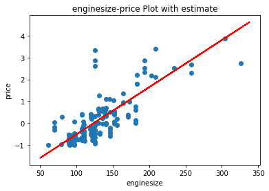

```python
plt.scatter(engineSizeDF["enginesize"] , engineSizeDF["price"])

x = np.random.randint(50,340,100)
plt.plot(x , linearEquationEngine3(x) , 'r')
plt.title("enginesize-price Plot with estimate");
plt.xlabel("enginesize");
plt.ylabel("price");
plt.show();
```

در این مرحله به دلیل این که یکی از خودرو ها هم enginesize و هم قیمت نامشخص دارد در نهایت قیمت برای آن دوباره NaN پیش بینی می شود.

در این جا چون curbweight نیز مورد خوبی برای افزایش خطی بود انتخاب شده و روند قبل عینا برای آن انجام شده و چون مقدار NaN در curbweight نمی باشد به مشکل گفته شده نمی خوریم و همه قیمت های نامشخص تخمین زده شده و پیش بینی می شوند.

```python
NaNPriceDF["price"] = linearEquationEngine3(NaNPriceDF["enginesize"])
NaNPriceDF

# one price is NaN because its engineSize was NaN from the start so I will choose curbweight now!
```

|  | car_ID | CarName | fueltype | carlength | carwidth | carheight | curbweight | cylindernumber | enginesize | horsepower | citympg | highwaympg | price |
| --- | --- | --- | --- | --- | --- | --- | --- | --- | --- | --- | --- | --- | --- |
| 4 | 5 | audi 100ls | 0 | 176.6 | 66.4 | 54.3 | 2824 | five | 136.0 | 115.0 | 18 | 22 | 0.259832 |
| 29 | 30 | dodge coronet custom (sw) | 0 | 173.2 | 66.3 | 50.2 | 2811 | four | 156.0 | 145.0 | 19 | 24 | 0.691552 |
| 31 | 32 | honda civic cvcc | 0 | 144.6 | 63.9 | 50.8 | 1819 | four | 92.0 | 76.0 | 31 | 38 | -0.689952 |
| 52 | 53 | mazda rx2 coupe | 0 | 159.1 | 64.2 | 54.1 | 1905 | four | 91.0 | 68.0 | 31 | 38 | -0.711538 |
| 53 | 54 | mazda rx-4 | 0 | 166.8 | 64.2 | 54.1 | 1945 | four | 91.0 | 68.0 | 31 | 38 | -0.711538 |
| 59 | 60 | mazda 626 | 0 | 177.8 | 66.5 | 53.7 | 2385 | four | 122.0 | 84.0 | 26 | 32 | -0.042372 |
| 62 | 63 | mazda rx-4 | 0 | 177.8 | 66.5 | 55.5 | 2410 | four | 122.0 | 84.0 | 26 | 32 | -0.042372 |
| 67 | 68 | buick electra 225 custom | 1 | 190.9 | 70.3 | 56.5 | 3515 | five | 183.0 | 123.0 | 22 | 25 | 1.274374 |
| 78 | 79 | mitsubishi outlander | 0 | 157.3 | 64.4 | 50.8 | 2004 | four | 92.0 | 68.0 | 31 | 38 | -0.689952 |
| 84 | 85 | mitsubishi mirage g4 | 0 | 173.2 | 66.3 | 50.2 | 2926 | four | 156.0 | 145.0 | 19 | 24 | 0.691552 |
| 87 | 88 | mitsubishi outlander | 0 | 172.4 | 65.4 | 51.6 | 2403 | four | 110.0 | 116.0 | 23 | 30 | -0.301404 |
| 88 | 89 | mitsubishi mirage g4 | 0 | 172.4 | 65.4 | 51.6 | 2403 | four | 110.0 | 116.0 | 23 | 30 | -0.301404 |
| 104 | 105 | nissan teana | 0 | 170.7 | 67.9 | 49.7 | 3071 | six | 181.0 | 160.0 | 19 | 25 | 1.231202 |
| 123 | 124 | plymouth valiant | 0 | 174.6 | 64.6 | 59.8 | 2535 | four | 122.0 | 88.0 | 24 | 30 | -0.042372 |
| 136 | 137 | saab 99gle | 0 | 186.6 | 66.5 | 56.1 | 2808 | four | NaN | 160.0 | 19 | 26 | NaN |
| 137 | 138 | saab 99e | 0 | 186.6 | 66.5 | 56.1 | 2847 | four | 121.0 | 160.0 | 19 | 26 | -0.063958 |
| 141 | 142 | subaru | 0 | 172.0 | 65.4 | 52.5 | 2145 | four | 108.0 | 82.0 | 32 | 37 | -0.344576 |
| 149 | 150 | subaru dl | 0 | 173.6 | 65.4 | 54.9 | 2650 | four | 108.0 | 111.0 | 23 | 23 | -0.344576 |
| 181 | 182 | toyouta tercel | 0 | 187.8 | 66.5 | 54.1 | 3151 | six | 161.0 | 156.0 | 19 | 24 | 0.799482 |
| 189 | 190 | vw dasher | 0 | 159.3 | 64.2 | 55.6 | 2254 | four | 109.0 | 90.0 | 24 | 29 | -0.322990 |

در این جا مقادیر دو ستون curbweight و قیمت را در یک دیتافریم جدید با نام curbWeightDF ذخیره می کنیم.

حال روند قبل تکرار شده و این دفعه بدون مشکل همه قیمت های نامشخص پیش بینی می شوند

```python
curbWeightDF = pd.concat([mainDataFrame["curbweight"] , mainDataFrame["price"]] , axis = 1)
```

```python
# y = 0.001510 * x - 3.848574 --> (4066 , 2.289727) , (1890 , -0.995306)
# y = 0.001463 * x - 3.657439 --> (4066 , 2.289727) , (1837 , -0.970537)
# y = 0.001525 * x - 3.911442 --> (4066 , 2.289727) , (2015 , -0.838310)
# y = 0.001553 * x - 4.024514 --> (4066 , 2.289727) , (2040 , -0.856523)

def linearEquationCurb1(x):
    return 0.001510 * x - 3.848574

def linearEquationCurb2(x):
    return 0.001463 * x - 3.657439

def linearEquationCurb3(x):
    return 0.001525 * x - 3.911442

def linearEquationCurb4(x):
    return 0.001553 * x - 4.024514


# linearEquationCurb3 is the best one
```

```python
sumFormula = ((curbWeightDF["price"] - linearEquationCurb3(curbWeightDF["curbweight"])) ** 2).sum()
```

```python
print("MSE: ")
sumFormula / len(curbWeightDF.index)
```

```
MSE:
```

```
0.3043813847026994
```

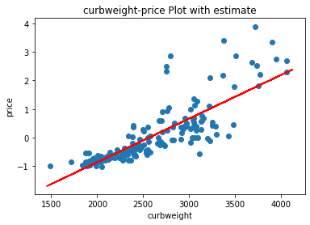

```python
plt.scatter(curbWeightDF["curbweight"] , curbWeightDF["price"])

x = np.random.randint(1450 , 4200 , 100)
plt.plot(x , linearEquationCurb3(x) , 'r')
plt.title("curbweight-price Plot with estimate");
plt.xlabel("curbweight");
plt.ylabel("price");
plt.show()
```

```python
NaNPriceDF["price"] = linearEquationCurb3(NaNPriceDF["curbweight"])
NaNPriceDF
```

|  | car_ID | CarName | fueltype | carlength | carwidth | carheight | curbweight | cylindernumber | enginesize | horsepower | citympg | highwaympg | price |
| --- | --- | --- | --- | --- | --- | --- | --- | --- | --- | --- | --- | --- | --- |
| 4 | 5 | audi 100ls | 0 | 176.6 | 66.4 | 54.3 | 2824 | five | 136.0 | 115.0 | 18 | 22 | 0.395158 |
| 29 | 30 | dodge coronet custom (sw) | 0 | 173.2 | 66.3 | 50.2 | 2811 | four | 156.0 | 145.0 | 19 | 24 | 0.375333 |
| 31 | 32 | honda civic cvcc | 0 | 144.6 | 63.9 | 50.8 | 1819 | four | 92.0 | 76.0 | 31 | 38 | -1.137467 |
| 52 | 53 | mazda rx2 coupe | 0 | 159.1 | 64.2 | 54.1 | 1905 | four | 91.0 | 68.0 | 31 | 38 | -1.006317 |
| 53 | 54 | mazda rx-4 | 0 | 166.8 | 64.2 | 54.1 | 1945 | four | 91.0 | 68.0 | 31 | 38 | -0.945317 |
| 59 | 60 | mazda 626 | 0 | 177.8 | 66.5 | 53.7 | 2385 | four | 122.0 | 84.0 | 26 | 32 | -0.274317 |
| 62 | 63 | mazda rx-4 | 0 | 177.8 | 66.5 | 55.5 | 2410 | four | 122.0 | 84.0 | 26 | 32 | -0.236192 |
| 67 | 68 | buick electra 225 custom | 1 | 190.9 | 70.3 | 56.5 | 3515 | five | 183.0 | 123.0 | 22 | 25 | 1.448933 |
| 78 | 79 | mitsubishi outlander | 0 | 157.3 | 64.4 | 50.8 | 2004 | four | 92.0 | 68.0 | 31 | 38 | -0.855342 |
| 84 | 85 | mitsubishi mirage g4 | 0 | 173.2 | 66.3 | 50.2 | 2926 | four | 156.0 | 145.0 | 19 | 24 | 0.550708 |
| 87 | 88 | mitsubishi outlander | 0 | 172.4 | 65.4 | 51.6 | 2403 | four | 110.0 | 116.0 | 23 | 30 | -0.246867 |
| 88 | 89 | mitsubishi mirage g4 | 0 | 172.4 | 65.4 | 51.6 | 2403 | four | 110.0 | 116.0 | 23 | 30 | -0.246867 |
| 104 | 105 | nissan teana | 0 | 170.7 | 67.9 | 49.7 | 3071 | six | 181.0 | 160.0 | 19 | 25 | 0.771833 |
| 123 | 124 | plymouth valiant | 0 | 174.6 | 64.6 | 59.8 | 2535 | four | 122.0 | 88.0 | 24 | 30 | -0.045567 |
| 136 | 137 | saab 99gle | 0 | 186.6 | 66.5 | 56.1 | 2808 | four | NaN | 160.0 | 19 | 26 | 0.370758 |
| 137 | 138 | saab 99e | 0 | 186.6 | 66.5 | 56.1 | 2847 | four | 121.0 | 160.0 | 19 | 26 | 0.430233 |
| 141 | 142 | subaru | 0 | 172.0 | 65.4 | 52.5 | 2145 | four | 108.0 | 82.0 | 32 | 37 | -0.640317 |
| 149 | 150 | subaru dl | 0 | 173.6 | 65.4 | 54.9 | 2650 | four | 108.0 | 111.0 | 23 | 23 | 0.129808 |
| 181 | 182 | toyouta tercel | 0 | 187.8 | 66.5 | 54.1 | 3151 | six | 161.0 | 156.0 | 19 | 24 | 0.893833 |
| 189 | 190 | vw dasher | 0 | 159.3 | 64.2 | 55.6 | 2254 | four | 109.0 | 90.0 | 24 | 29 | -0.474092 |

در نهایت مقادیر حاصل از curbweight مد نظر ما خواهد بود.

با استفاده روش گفته شده در این پروژه می توان به تابع تخمینی با MSE کم تر از 0.5 رسید و قیمت ها را پیش بینی کرد.

می توان با داشتن مقادیر واقعی قیمت های نامشخص بررسی کرد که تابع تخمین تا چه حد در واقعیت می تواند درست عمل کند.

برای پیدا کردن توابع کتابخانه pandas و matplotlib به documentation آن ها مراجعه شده است.

```python
%%html
<style>.text_cell .rendered_html * {direction: rtl; text-align: right;}</style>
```